# Homework 2 Stochastic Gradient Descent

```python
import numpy as np
import matplotlib.pyplot as plt
import pandas as pd
```

## Exercise 1: SGD vs GD on a Simple 1D Regression Problem

Consider the synthetic dataset

$$ x^{(i)} = \frac{i}{N},\qquad y^{(i)} = 2x^{(i)} + 1 + \varepsilon^{(i)}, \qquad \varepsilon^{(i)}\sim\mathcal N(0,0.01), $$

with $N = 200$. We model the data with a linear function:

$$ f_\Theta(x) = \Theta_0 + \Theta_1 x = \Theta^T \tilde{x}, $$

if we define $\tilde{x} = [1, x]$ as we did during the lab session.

1. Implement the MSE loss:

   $$ \mathcal L(\Theta)=\frac{1}{N}\sum_{i=1}^N (f_\Theta(x^{(i)}) - y^{(i)})^2. $$
2. Implement **full GD** and **SGD** (mini-batch) using batch sizes:
   - $N_{\text{batch}} = 1$,
   - $N_{\text{batch}} = 10$,
   - $N_{\text{batch}} = 50$,
   - $N_{\text{batch}} = N$ (this recovers GD).
3. Plot for each method:
   - the loss curve (loss vs epoch),
   - the trajectory of parameters $(\Theta_0,\Theta_1)$ in the 2D parameter space. This is similar to what you did in the previous homework: simply plot the value of $\Theta_0^{(k)}$ and $\Theta_1^{(k)}$ for all the $k$s in a 2-dimensional plot.
4. Discuss:
   - Why GD is smooth but slow for large $N$,
   - Why SGD is noisy but progresses faster,
   - How batch size affects the noise level and convergence stability.

```python
# Set random seed for reproducibility
np.random.seed(42)

# --- 1. Data Generation ---
N = 200
X_raw = np.linspace(0, 1, N)
# Add bias term (column of ones) to the feature matrix
X = np.c_[np.ones(N), X_raw]

# Generate target y = 2x + 1 + noise
noise = np.random.normal(0, np.sqrt(0.01), N)
y = 2 * X_raw + 1 + noise
y = y.reshape(-1, 1) # Reshape to column vector (N, 1)

# --- 2. Helper Functions ---

def mse_loss(theta, X_data, y_data):
    # Compute Mean Squared Error: (1/N) * sum((y_pred - y_true)^2)
    N_samples = len(y_data)
    predictions = X_data @ theta
    cost = (1 / N_samples) * np.sum((predictions - y_data) ** 2)
    return cost

def get_gradient(theta, X_batch, y_batch):
    # Compute gradient of MSE for a specific batch
    # Gradient formula: (2/m) * X^T * (X*theta - y)
    m = len(y_batch)
    predictions = X_batch @ theta
    gradient = (2 / m) * X_batch.T @ (predictions - y_batch)
    return gradient

print(f"Data shapes: X: {X.shape}, y: {y.shape}")
```

```
Data shapes: X: (200, 2), y: (200, 1)
```

```python
def train_sgd(X, y, batch_size, eta=0.1, epochs=50):
    # Performs Stochastic Gradient Descent (or Mini-Batch/Full GD depending on batch_size).

    N = len(y)
    # Initialize parameters randomly
    theta = np.random.randn(2, 1)

    # Lists to store training history
    theta_history = [theta.copy()]
    loss_history_epoch = [mse_loss(theta, X, y)]

    for epoch in range(epochs):
        # Shuffle dataset indices at the start of each epoch
        indices = np.random.permutation(N)
        X_shuffled = X[indices]
        y_shuffled = y[indices]

        # Iterate over mini-batches
        for i in range(0, N, batch_size):
            # Extract current batch
            X_batch = X_shuffled[i : i + batch_size]
            y_batch = y_shuffled[i : i + batch_size]

            # Compute gradient and update parameters
            grad = get_gradient(theta, X_batch, y_batch)
            theta = theta - eta * grad

            # Record parameter trajectory (for visualization)
            theta_history.append(theta.copy())

        # Compute and record loss on the FULL dataset at the end of the epoch
        current_loss = mse_loss(theta, X, y)
        loss_history_epoch.append(current_loss)

    return np.array(theta_history).squeeze(), np.array(loss_history_epoch)
```

```python
# --- 3. Execution and Visualization ---

# Hyperparameters
eta = 0.1
epochs = 50
batch_sizes = [1, 10, 50, 200] # 200 corresponds to Full GD

results = {}

# Run training for each batch size configuration
for bs in batch_sizes:
    thetas, losses = train_sgd(X, y, batch_size=bs, eta=eta, epochs=epochs)
    results[bs] = {'thetas': thetas, 'losses': losses}

print("Training complete.")
```

```
Training complete.
```

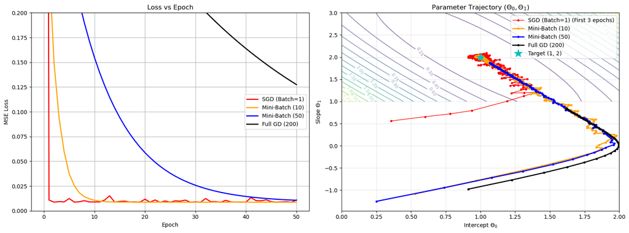

```python
def quad_levelsets_mse(X, y, theta0_lim=(0, 2), theta1_lim=(1, 3),
                       ngrid=200, ncontours=20, title=None):
    theta0_vals = np.linspace(theta0_lim[0], theta0_lim[1], ngrid)
    theta1_vals = np.linspace(theta1_lim[0], theta1_lim[1], ngrid)
    T0, T1 = np.meshgrid(theta0_vals, theta1_vals)
    Z = np.zeros_like(T0)

    for i in range(ngrid):
        for j in range(ngrid):
            theta = np.array([[T0[i, j]], [T1[i, j]]])
            Z[i, j] = mse_loss(theta, X, y)

    cs = plt.contour(T0, T1, Z, levels=ncontours, cmap='viridis', alpha=0.5)
    plt.clabel(cs, inline=True, fontsize=8)

    if title:
        plt.title(title)

    plt.xlabel(r'Intercept $\Theta_0$')
    plt.ylabel(r'Slope $\Theta_1$')
    plt.grid(alpha=0.3)


# Plotting
fig, (ax1, ax2) = plt.subplots(1, 2, figsize=(16, 6))

# Plot 1: Loss vs Epoch
colors = {1: 'red', 10: 'orange', 50: 'blue', 200: 'black'}
labels = {1: 'SGD (Batch=1)', 10: 'Mini-Batch (10)',
          50: 'Mini-Batch (50)', 200: 'Full GD (200)'}

for bs in batch_sizes:
    ax1.plot(results[bs]['losses'], label=labels[bs],
             color=colors[bs], linewidth=2)

ax1.set_title("Loss vs Epoch")
ax1.set_xlabel("Epoch")
ax1.set_ylabel("MSE Loss")
ax1.set_ylim(0, 0.2)
ax1.grid(True)
ax1.legend()

# Plot 2: Parameter Trajectories
plt.sca(ax2)

quad_levelsets_mse(
    X, y,
    theta0_lim=(0, 2),
    theta1_lim=(1, 3),
    title="Parameter Trajectory $(\\Theta_0, \\Theta_1)$"
)

# Overlay trajectories
for bs in batch_sizes:
    traj = results[bs]['thetas']
    alpha = 0.3 if bs == 1 else 0.8
    lw = 1 if bs == 1 else 2

    if bs == 1:
        # Plot only first 600 steps for SGD to avoid overcrowding
        plot_data = traj[:600]
        label_add = " (First 3 epochs)"
    else:
        plot_data = traj
        label_add = ""

    ax2.plot(plot_data[:, 0], plot_data[:, 1], '.-',
             label=labels[bs] + label_add,
             color=colors[bs], linewidth=lw)

ax2.plot(1, 2, 'c*', markersize=15, label='Target (1, 2)')
ax2.legend()
ax2.grid(True)

plt.tight_layout()
plt.show()
```

```python
'''
El objetivo es ajustar una línea recta ($y = \theta_0 + \theta_1 x$) a unos datos sintéticos generados por la fórmula
$y = 2x + 1 + \text{ruido}$. Tienes $N=200$ puntos de datos. La tarea es comparar cómo aprenden los parámetros
($\theta_0, \theta_1$) diferentes variantes del Descenso de Gradiente según el tamaño del lote (batch size).


Pregunta: ¿Por qué el Full GD es suave (smooth) pero lento para N grandes?
Respuesta: "El Full GD es suave porque calcula el gradiente exacto promediando el error de todos los puntos del dataset
($\frac{1}{N}\sum \nabla \mathcal{L}_i$). Esto elimina el ruido, por lo que el paso siempre va en la dirección de
máximo descenso. Es computacionalmente ineficiente. Para mover los pesos una sola vez, tienes que procesar
el dataset entero (millones de cálculos si $N$ es grande). Si el dataset no cabe en memoria, es inviable."


Pregunta: ¿Por qué el SGD es ruidoso (noisy) pero progresa más rápido?
Respuesta: "Es ruidoso porque estimamos el gradiente usando solo un punto aleatorio. Ese punto puede ser un 'outlier'
o tener ruido, lo que hace que el gradiente apunte en una dirección incorrecta momentáneamente (zig-zag).


Pregunta: ¿Cómo afecta el tamaño del batch (batch size) al nivel de ruido y la estabilidad?
Respuesta: "Existe un compromiso (trade-off):
Batch pequeño (ej. 1 o 10): Mucho ruido en la trayectoria de los parámetros. Esto puede ser bueno porque el ruido
ayuda a escapar de mínimos locales o puntos de silla (en redes neuronales), pero impide converger exactamente
al mínimo final (se queda bailando alrededor).
Batch grande (ej. 50 o N): Menos ruido, trayectoria más estable y recta. Permite usar tasas de aprendizaje ($\eta$)
más grandes, pero cada paso es más costoso de calcular."
'''
```

## Exercise 2: Variance of the Stochastic Gradient (1D Experiment)

Fix a parameter vector $\Theta$, and repeatedly draw random mini-batches of the same size.

1. Choose batch sizes:

   $$ N_{\text{batch}} \in \{1, 5, 20, N\}. $$
2. At the **same** $\Theta$, compute:

   $$ g_k = \nabla_\Theta \mathcal L(\Theta; \mathcal M_k) $$

   for 100 randomly sampled batches $\mathcal M_k$.
3. For each batch size, compute the empirical variance:

   $$ \mathrm{Var}(g) = \frac{1}{100}\sum_{k=1}^{100} \|g_k - \bar g\|^2, $$

   where $\bar{g}$ is the average of the $g_k$s, defined as:

   $$ \bar{g} = \frac{1}{100} \sum_{k=1}^{100} g_k. $$
4. Plot the variance as a function of the batch size.
5. Comment:
   - Why the variance decreases with larger batches,
   - Why SGD becomes more stable as $N_{\text{batch}}$ increases,
   - The trade-off between stability and computational cost.

```python
# --- Variance Experiment ---

batch_sizes = [1, 5, 20, N]
fixed_theta = np.array([[1.0], [1.0]]) # Fix parameters at an arbitrary point
variances = []

for bs in batch_sizes:
    gradients_k = []

    # Perform 100 trials of gradient estimation
    for _ in range(100):
        # Sample a random mini-batch
        indices = np.random.choice(N, bs, replace=False)
        X_batch = X[indices]
        y_batch = y[indices]

        # Compute gradient on this batch
        g = get_gradient(fixed_theta, X_batch, y_batch)
        gradients_k.append(g)

    gradients_k = np.array(gradients_k)

    # Compute the mean gradient vector across trials
    g_bar = np.mean(gradients_k, axis=0)

    # Compute squared Euclidean distance from the mean for each trial
    diffs = gradients_k - g_bar
    squared_norms = np.sum(diffs**2, axis=(1, 2))

    # Calculate empirical variance (mean of squared norms)
    variance = np.mean(squared_norms)
    variances.append(variance)

    print(f"Batch Size: {bs:3d} | Empirical Variance: {variance:.5f}")
```

```
Batch Size:   1 | Empirical Variance: 0.83940
Batch Size:   5 | Empirical Variance: 0.13400
Batch Size:  20 | Empirical Variance: 0.02526
Batch Size: 200 | Empirical Variance: 0.00000
```

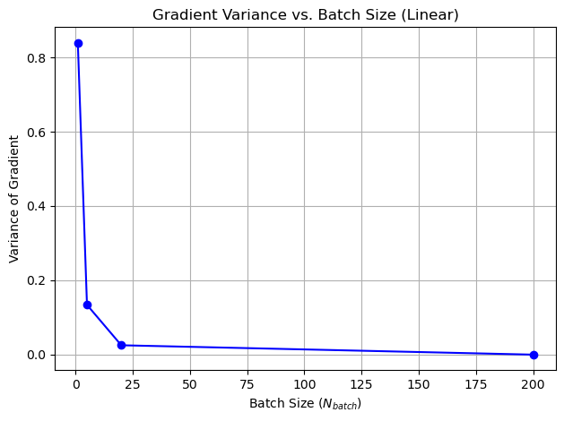

```python
# Linear Scale
plt.plot(batch_sizes, variances, 'bo-')
plt.title("Gradient Variance vs. Batch Size (Linear)")
plt.xlabel("Batch Size ($N_{batch}$)")
plt.ylabel("Variance of Gradient")
plt.grid(True)

plt.tight_layout()
plt.show()
```

```python
'''
En este experimento, congelas los parámetros $\Theta$ en un punto fijo (no entrenas la red, solo tomas una foto estática).
Luego, calculas el gradiente 100 veces usando diferentes grupos aleatorios de datos (mini-batches) de tamaño 1, 5, 20 y 200.
El objetivo es medir cuánto "baila" o cambia el vector gradiente dependiendo de cuántos datos usas para calcularlo.


Pregunta: ¿Por qué el SGD se vuelve más estable al aumentar $N_{batch}$?
Respuesta: "Al reducir la varianza, reducimos el ruido en la estimación de la dirección de descenso.
Con $N_{batch}=1$, el vector gradiente apunta a veces en direcciones erróneas debido a datos atípicos (outliers),
lo que causa un camino en zig-zag muy caótico.
Con $N_{batch}$ grande, el vector gradiente se parece mucho más al gradiente 'verdadero' (el de todo el dataset),
por lo que el paso es más confiable y directo hacia el mínimo."


Pregunta: Explica el Trade-off (Compromiso) entre estabilidad y coste computacional.
Respuesta: "Es un problema de rendimientos decrecientes:
Coste: Calcular el gradiente para un batch de tamaño $B$ cuesta $O(B)$ operaciones. Aumentar $B$ hace cada paso más lento.
Beneficio: Aumentar $B$ reduce el ruido ($\frac{1}{B}$), pero llega un punto donde añadir más datos apenas mejora
la precisión del gradiente, pero sigue aumentando el coste linealmente.
El punto dulce (Sweet Spot): Usar mini-batches (ej. 32, 64) nos da suficiente estabilidad para usar vectorización
(GPU) eficiente, sin el coste prohibitivo de procesar todo el dataset (Full GD) en cada paso."
'''
```

## Exercise 3: SGD in 2D

We now study SGD on the 2D non-convex function:

$$ \mathcal{L}(\Theta_1,\Theta_2) = (\Theta_1^2 - 1)^2 + 10(\Theta_2 - \Theta_1^2)^2. $$

This function has:

- two valleys,
- multiple stationary points,
- strong curvature differences.
1. Treat $\Theta = (\Theta_1,\Theta_2)$ as a “parameter vector” updated by SGD:

   $$ \Theta_{k+1} = \Theta_k - \eta\, g_k, $$

   where the ``gradient batch'' $g_k$ is simulated by adding noise to the gradient:

   $$ g_k = \nabla \mathcal{L}(\Theta_k) + \varepsilon_k, \qquad \varepsilon_k \sim \mathcal{N}(0, \sigma^2I), $$

   where $\sigma^2$ is called **noise level** and represent the variance of the noise. Try different values of $\sigma^2$ to answer the following questions. *Note: $\sigma^2$ should always be lower than 1*.
2. Plot:
   - level sets of $\mathcal{L}(\Theta_1,\Theta_2)$,
   - trajectories of SGD for different noise levels and step sizes.
3. Discuss:
   - How noise helps escape shallow minima or bad regions,
   - How too much noise prevents convergence,

```python
# --- Function Definitions ---

def L_nonconvex(theta):
    # Non-convex function definition
    x, y = theta[0], theta[1]
    return (x**2 - 1)**2 + 10 * (y - x**2)**2

def grad_nonconvex(theta):
    # Analytical gradient calculation
    x, y = theta[0], theta[1]
    grad_x = 4 * x * (x**2 - 1) - 40 * x * (y - x**2)
    grad_y = 20 * (y - x**2)
    return np.array([grad_x, grad_y])

def run_noisy_sgd(grad_func, theta_0, eta=0.01, sigma=0.0, n_iters=100):
    # Simulates SGD by adding Gaussian noise to the true gradient
    theta = np.array(theta_0, dtype=float)
    history = [theta.copy()]

    for _ in range(n_iters):
        # Compute exact gradient
        true_grad = grad_func(theta)

        # Generate Gaussian noise vector
        noise = np.random.normal(0, sigma, size=2)

        # Add noise to gradient
        noisy_grad = true_grad + noise

        # Parameter update
        theta = theta - eta * noisy_grad
        history.append(theta.copy())

    return np.array(history)


def quad_levelsets(ax, X, Y, Z, levels):
    ax.contour(X, Y, Z, levels=levels, cmap='viridis', alpha=0.6)


x_range = np.linspace(-2.5, 2.5, 200)
y_range = np.linspace(-2, 3, 200)
X, Y = np.meshgrid(x_range, y_range)
Z = (X**2 - 1)**2 + 10 * (Y - X**2)**2
```

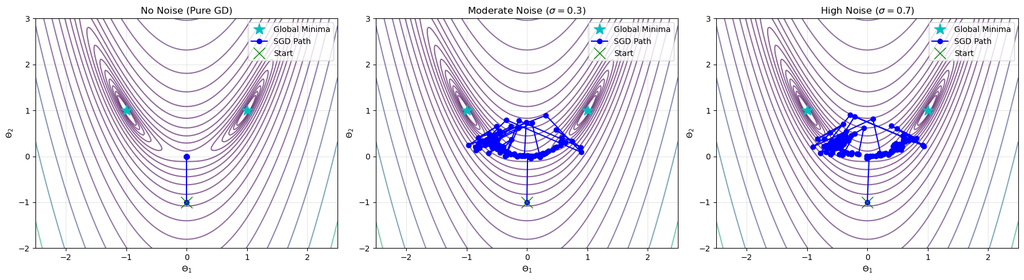

```python
# --- Visualization ---
theta_start = [0.0, -1.0] # Initial point on the ridge
eta = 0.05
n_iters = 100
sigmas = [0.0, 0.3, 0.7] # Different noise levels
labels = ['No Noise (Pure GD)',
          r'Moderate Noise ($\sigma=0.3$)',
          r'High Noise ($\sigma=0.7$)']

# Create figure
fig, axes = plt.subplots(1, 3, figsize=(18, 5))

for i, sigma in enumerate(sigmas):
    ax = axes[i]

    # Run simulation
    traj = run_noisy_sgd(
        grad_nonconvex,
        theta_start,
        eta=eta,
        sigma=sigma,
        n_iters=n_iters)

    quad_levelsets(
        ax,
        X, Y, Z,
        levels=np.logspace(-1, 3, 20))

    # Plot minima
    ax.plot([-1, 1], [1, 1], 'c*', markersize=15, label='Global Minima')

    # Plot trajectory
    ax.plot(traj[:, 0], traj[:, 1], 'bo-', label='SGD Path')
    ax.plot(theta_start[0], theta_start[1], 'gx', markersize=15, label='Start')

    ax.set_title(labels[i])
    ax.set_xlabel(r'$\Theta_1$')
    ax.set_ylabel(r'$\Theta_2$')
    ax.set_xlim([-2.5, 2.5])
    ax.set_ylim([-2, 3])
    ax.grid(True, alpha=0.3)
    ax.legend()

plt.tight_layout()
plt.show()
```

```python
'''
Trabajas con una función que tiene dos valles (dos mínimos globales en $(-1, 1)$ y $(1, 1)$) separados por una "colina" o
cresta en el medio. En lugar de usar datos reales para generar estocasticidad (como en el Ejercicio 1), aquí simulamos el
SGD añadiendo ruido artificial (Gaussiano) al gradiente verdadero.
El objetivo es ver cómo el "ruido" ($\sigma$) afecta la capacidad del algoritmo para navegar por este terreno complicado.


Pregunta: ¿Cómo ayuda el ruido a escapar de mínimos locales poco profundos o regiones malas? (Saddle Points)
Respuesta: "El ruido rompe la simetría y aporta 'energía' extra.
Puntos de Silla (Saddle Points): En lugares como $(0,0)$, el gradiente es cero ($\nabla \mathcal{L}=0$).
Un GD puro se quedaría atascado allí para siempre o bajaría muy lento. El ruido del SGD le da un 'empujón'
aleatorio que lo saca de ese equilibrio inestable rápidamente.


Pregunta: ¿Cómo impide el exceso de ruido la convergencia?
Esto es básicamente una Caminata Aleatoria (Random Walk). El algoritmo nunca se asentará en el punto óptimo,
sino que bailará caóticamente a su alrededor. La distancia al mínimo estará limitada por la varianza del ruido
y el learning rate ($\eta$)."
'''
```

## Exercise 4: An ML Project with SGD

For the final exercise, you will train a simple machine learning model using SGD on a real prediction task. To begin, download the Kaggle dataset: https://www.kaggle.com/datasets/mirichoi0218/insurance.

It contains approximately 1300 samples, and its associated task is to predict **individual medical insurance cost** based on numerical features:

- `age`
- `bmi`
- `children`

The task is:

$$ \text{charges} \approx f_\Theta(\text{age},\text{bmi},\text{children}). $$

We use a simple linear model:

$$ f_\Theta(x) = \Theta^T \tilde{x}. $$

1. Load & preprocess the dataset
   - Download `insurance.csv` from Kaggle.
   - Select numerical columns:  
     `["age", "bmi", "children"]`.
   - Standardize each feature (mean 0, variance 1).
   - Standardize the target `"charges"`.
   - Add a bias column.
2. Consider the MSE loss:

   $$ \mathcal{L}(\Theta)=\frac{1}{N}\sum_{i=1}^N (\Theta^T \tilde{x}^{(i)} - \tilde{y}^{(i)})^2. $$

   Implement:
   - Full GD
   - SGD with batch sizes 1, 10, 50

   Use a fixed learning rate $\eta=10^{-2}$ and a fixed number of epochs (equivalently, a fixed amount of maximum iterations for GD) of your choice.
3. Compare GD and SGD For each method:
   - Plot the loss vs epoch.
   - Plot the L2 norm of the **full gradient** $\|\nabla \mathcal{L}(\Theta_k)\|$ measured at the end of every epoch.
   - Report the final learned parameters.
4. Discuss:
   - Why GD gives a smooth curve and SGD oscillates.
   - Why larger batches reduce noise but cost more per iteration.
   - Why all methods roughly converge to the same region.
   - Why SGD is more suitable for large datasets, even when noisy.

```python
# --- 1. Data Loading and Synthetic Generation ---
df = pd.read_csv('insurance.csv')

# Select features and target
features = ["age", "bmi", "children"]
target = "charges"

# Extract features and target
X_raw = df[features].values
y_raw = df[target].values

# --- 2. Preprocessing ---
# Standardize features (Z-score normalization)
X_mean = X_raw.mean(axis=0)
X_std = X_raw.std(axis=0)
X_scaled = (X_raw - X_mean) / X_std

# Standardize target variable
y_mean = y_raw.mean()
y_std = y_raw.std()
y_scaled = (y_raw - y_mean) / y_std
y_scaled = y_scaled.reshape(-1, 1)

# Add bias term (column of ones)
X_b = np.c_[np.ones((X_scaled.shape[0], 1)), X_scaled]

print(f"Data shape: {X_b.shape}")
print(f"Features (first 3 rows):\n{X_b[:3]}")
```

```
Data shape: (1338, 4)
Features (first 3 rows):
[[ 1.         -1.43876426 -0.45332    -0.90861367]
 [ 1.         -1.50996545  0.5096211  -0.07876719]
 [ 1.         -0.79795355  0.38330685  1.58092576]]
```

```python
# --- 3. Training Loop ---
def compute_full_loss_and_grad_norm(X, y, theta):
    # Computes MSE and Gradient Norm on the full dataset
    N = len(y)
    predictions = X @ theta
    errors = predictions - y

    loss = (1/N) * np.sum(errors**2)

    full_grad = (2/N) * X.T @ errors
    grad_norm = np.linalg.norm(full_grad)

    return loss, grad_norm

def train_linear_regression(X, y, batch_size, eta=0.01, epochs=50):
    N = len(y)
    # Initialize Theta (random small values)
    theta = np.random.randn(X.shape[1], 1) * 0.1

    loss_history = []
    grad_norm_history = []

    for epoch in range(epochs):
        # Shuffle data
        indices = np.random.permutation(N)
        X_shuffled = X[indices]
        y_shuffled = y[indices]

        # Mini-batch updates
        for i in range(0, N, batch_size):
            X_batch = X_shuffled[i:i+batch_size]
            y_batch = y_shuffled[i:i+batch_size]

            # Compute Gradient for batch
            # Note: We divide by batch_size (len(y_batch)) for the gradient average
            current_bs = len(y_batch)
            preds = X_batch @ theta
            grad = (2/current_bs) * X_batch.T @ (preds - y_batch)

            # Update
            theta = theta - eta * grad

        # End of Epoch: Record metrics on FULL dataset
        loss, g_norm = compute_full_loss_and_grad_norm(X, y, theta)
        loss_history.append(loss)
        grad_norm_history.append(g_norm)

    return theta, loss_history, grad_norm_history
```

```
Training models...
Batch Size 1: Final Loss = 0.9123
Batch Size 10: Final Loss = 0.8841
Batch Size 50: Final Loss = 0.8799
Batch Size 1338: Final Loss = 0.8938
```

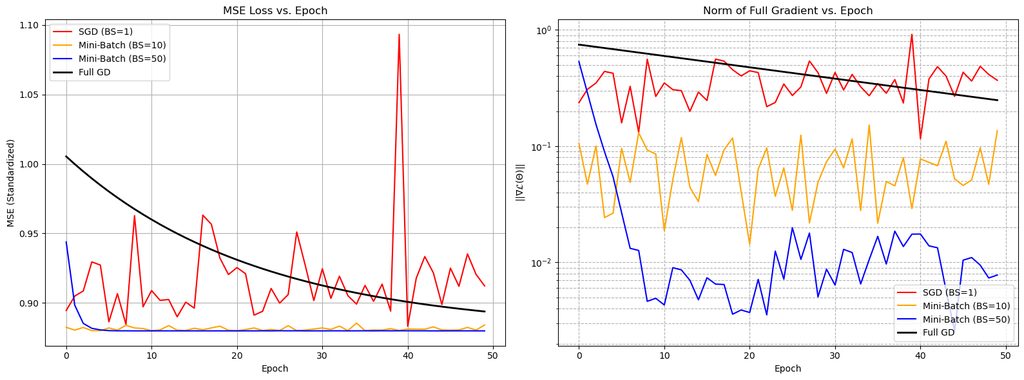

```
--- Learned Parameters (Standardized Space) ---
Method               | Bias       | Age        | BMI        | Children
---------------------------------------------------------------------------
SGD (BS=1)           | -0.1325     | 0.2126     | 0.1106     | -0.0228
Mini-Batch (BS=10)   | 0.0251     | 0.3051     | 0.2119     | 0.0772
Mini-Batch (BS=50)   | 0.0007     | 0.2812     | 0.1678     | 0.0562
Full GD              | -0.0087     | 0.1960     | 0.0916     | 0.0585
```

```python
# Parameters
eta = 0.01
epochs = 50
batch_sizes = [1, 10, 50, len(y_scaled)] # Include Full GD (batch_size = N)
labels = {1: 'SGD (BS=1)', 10: 'Mini-Batch (BS=10)', 50: 'Mini-Batch (BS=50)', len(y_scaled): 'Full GD'}
colors = {1: 'red', 10: 'orange', 50: 'blue', len(y_scaled): 'black'}

results = {}

print("Training models...")
for bs in batch_sizes:
    theta_opt, losses, grads = train_linear_regression(X_b, y_scaled, batch_size=bs, eta=eta, epochs=epochs)
    results[bs] = {'theta': theta_opt, 'loss': losses, 'grad': grads}

    # Print final parameters (unscaled roughly) for inspection
    print(f"Batch Size {bs}: Final Loss = {losses[-1]:.4f}")

# Plot Results
fig, (ax1, ax2) = plt.subplots(1, 2, figsize=(16, 6))

for bs in batch_sizes:
    ax1.plot(results[bs]['loss'], label=labels[bs], color=colors[bs], linewidth=2 if bs==len(y_scaled) else 1.5)

ax1.set_title("MSE Loss vs. Epoch")
ax1.set_xlabel("Epoch")
ax1.set_ylabel("MSE (Standardized)")
ax1.grid(True)
ax1.legend()

for bs in batch_sizes:
    ax2.plot(results[bs]['grad'], label=labels[bs], color=colors[bs], linewidth=2 if bs==len(y_scaled) else 1.5)

ax2.set_title("Norm of Full Gradient vs. Epoch")
ax2.set_xlabel("Epoch")
ax2.set_ylabel(r"$||\nabla \mathcal{L}(\Theta)||$")
ax2.set_yscale('log') # Log scale for gradient norm
ax2.grid(True, which="both", linestyle='--')
ax2.legend()

plt.tight_layout()
plt.show()

# Report Learned Parameters
print("\n--- Learned Parameters (Standardized Space) ---")
print(f"{'Method':<20} | {'Bias':<10} | {'Age':<10} | {'BMI':<10} | {'Children':<10}")
print("-" * 75)
for bs in batch_sizes:
    t = results[bs]['theta'].flatten()
    print(f"{labels[bs]:<20} | {t[0]:.4f}     | {t[1]:.4f}     | {t[2]:.4f}     | {t[3]:.4f}")
```

```python
'''
Tienes un dataset real (insurance.csv) con 1338 personas.
El paso clave aquí fue el preprocesamiento: estandarizar los datos (restar media, dividir por desviación estándar)
para que el algoritmo no sufra por las diferentes escalas (años vs hijos).


Pregunta: ¿Por qué el GD da una curva suave y el SGD oscila?
Respuesta: Full GD: Usa toda la información disponible ($N=1338$) para calcular el gradiente exacto
($\nabla \mathcal{L}$). No hay aleatoriedad, así que la pérdida baja monótonamente en una curva suave y perfecta.
SGD (Batch=1): Estima el gradiente con una sola persona. Si esa persona es un caso atípico, el gradiente apuntará
en una dirección extraña, aumentando la pérdida momentáneamente. Esas fluctuaciones crean la oscilación."


Pregunta: ¿Por qué los batches más grandes reducen el ruido pero cuestan más?
Respuesta: Reducción de Ruido: La varianza del gradiente disminuye con $1/B$. Un batch de 50 es mucho más representativo
de la población que uno de 1, por lo que el paso es más estable.
Coste: Calcular el gradiente implica operaciones matriciales. Procesar 50 datos cuesta 50 veces más operaciones
de punto flotante que procesar 1."


Pregunta: ¿Por qué todos los métodos convergen "más o menos" a la misma región?
Respuesta: "Cualquier algoritmo de gradiente bien configurado (con un $\eta$ que cumpla las condiciones de Robbins-Monro)
acabará cayendo por gravedad hacia el fondo de ese cuenco, independientemente de si baja en línea recta (GD)
o dando tumbos (SGD)."


Pregunta: ¿Por qué el SGD es más adecuado para grandes datasets, aunque sea ruidoso?
Respuesta: "SGD: Da miles de pasos con el mismo coste computacional que el GD usa para dar uno solo.
Aunque cada paso sea imperfecto, llegarás al destino mucho más rápido que esperando a calcular el paso perfecto."
'''
```